# AMS223 Time Series Analysis Homework 1

Cheng-Han Yu

October 10, 2013

**Textbook**: Prado, R. and M. West (2010) *Time Series - Modeling, Computation and Inference*. New York: Chapman & Hall/CRC.

# Homework Problems

1. **Chapter 1 Problem 2** Consider the AR(1) model $y_t = \phi y_{t-1} + \epsilon _t$, with $\epsilon _t \sim N(0, v)$.
   1. Find the MLE of $(\phi, v)$ for the conditional likelihood.
   2. Find the MLE of $(\phi, v)$ for the unconditional likelihood (1.17).
   3. Assume that $v$ is known. Find the MAP estimator of $\phi$ under a uniform prior $p(\phi) = U(\phi|-1, 1)$ for the conditional and unconditional likelihoods.
2. **Chapter 1 Problem 3** Show that the distributions of $(\phi|\mathbf{y}, \mathbf{F}))$ and $(v|\mathbf{y}, \mathbf{F})$ obtained for the AR(1) reference analysis are those given in Example 1.6.
3. **Chapter 2 Problem 4** Show that the distributions of $(\phi|\mathbf{y}, \mathbf{F}))$ and $(v|\mathbf{y}, \mathbf{F}))$ obtained for the AR(1) conjugate analysis are those given in Example 1.7.
4. **Chapter 2 Problem 5** Consider the following models:
   1. $y_t = \phi_1 y_{t-1} + \phi _2 y_{t-2} + \epsilon _t$
   2. $y_t = a \cos(2 \pi \omega _0 t) + b \sin(2 \pi \omega _0 t) + \epsilon _t$
   1. Sample 200 observations from each model using your favorite choice of the parameters. Make sure your choice of $(\phi _1, \phi _2)$ in model (1) lies in the stationary region. That is, choose $\phi _1$ and $\phi _2$ such that $-1 < \phi _2 < 1$, $\phi _1 < 1 - \phi _2$, and $\phi _1 > \phi _2 - 1$.
   2. Find the MLEs of the parameters in model (1) and (2). Use the conditional likelihood for model (1).
   3. Find the MAP estimators of the model parameters under the reference prior. Again, use the conditional likelihood for model (1).
   4. Sketch $p(v|y_{1:n})$ and $p(\phi _1, \phi _2 | y_{1:n})$ for model (1).
   5. Sketch $p(a, b|y_{1:n})$ and $p(v|y_{1:n})$ in model (2).
   6. Perform a conjugate Bayesian analysis, i.e., repeat (c) to (e) assuming conjugate prior distributions in both models. Study the sensitivity of the posterior distributions to the choice of the hyperparameters in the prior.
5. **Chapter 2 Problem 7** Sample 1000 observations from the model (1.1). Using a prior distribution of the form $p(\phi^{(i)}) = N(m, c)$, for some $c$ and $i = 1, 2$, $p(\theta) = U(\theta|-a, a)$ and $p(v) = IG(\alpha _0, \beta _0)$, obtain samples from the joint posterior distribution by implementing a Metropolis-Hasting algorithm.
6. For each of the Chapter 1 datasets: (a) plot the data; (b) plot the sample autocorrelation functions. For the SOI series: smooth the series using moving averages (try different orders and weights). For the USA GDP time series: plot the first and second differences and the corresponding sample autocorrelation functions.

Here we cite some R packages, including (Xie 2016). It also relied on the R packages (Plummer et al. 2015), (Gandrud 2016) and (Nychka et al. 2016).

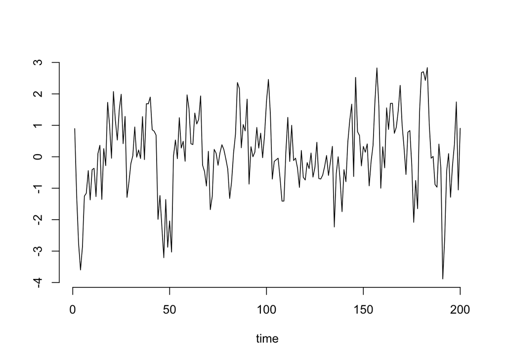

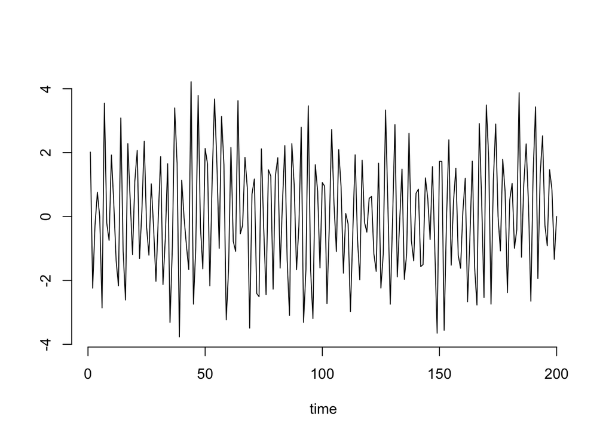

200 observations from (3) and (4)

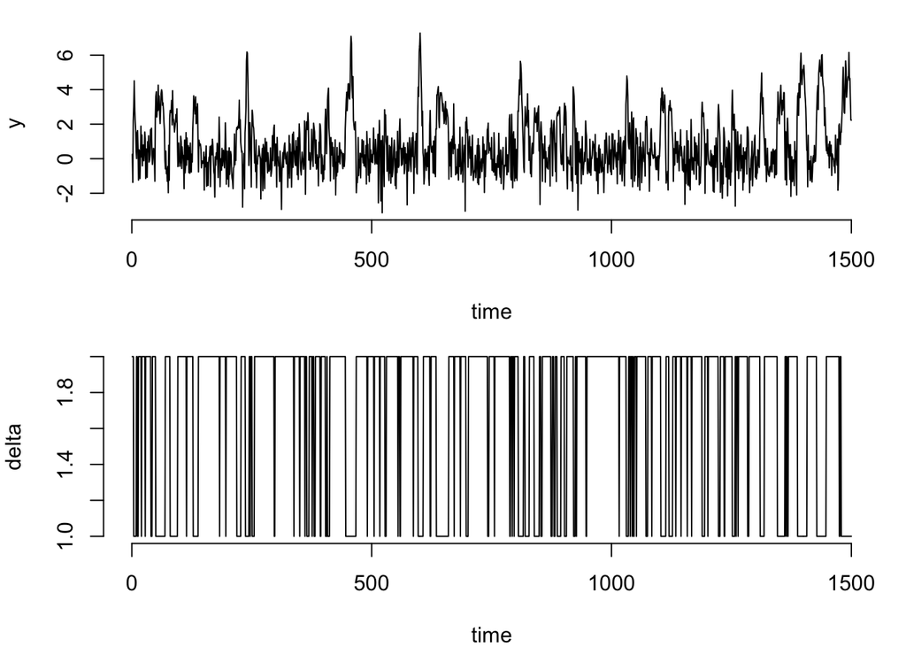

[figure not shown]

Posterior Summary

|  | effective size | post. mean | 2.5% quantile | 97.5% quantile |
| --- | --- | --- | --- | --- |
| $\phi_1$ | 664.20 | 0.91 | 0.91 | 0.91 |
| $\phi_2$ | 1304.99 | -0.22 | -0.22 | -0.22 |
| $v$ | 2000.00 | 1.01 | 0.94 | 1.08 |
| $\theta$ | 651.06 | -1.50 | -1.50 | -1.47 |

# R Code

```r
# List of packages
PackageUsed <- c("knitr", "pscl", "coda", "parallel",
"doParallel", "tikzDevice", "mvtnorm", "fields", "repmis")
# Load packages
lapply(PackageUsed, library, character.only = TRUE)
knitr::read_chunk("AMS223_HW1_P1.R")
knitr::read_chunk("AMS223_HW1_P4.R")
knitr::read_chunk("AMS223_HW1_P5.R")
knitr::read_chunk("AMS_223_HW1_Q6.R")
phi <- 0.9
v <- 1
y0 <- 0.1
n <- 100
y <- rep(NA, n)
# y[1] <- y0
set.seed(123456)
for (i in 1:n) {
    if (i == 1) {
        y[i] <- phi * y0 + rnorm(1, 0, v)
    } else {
        y[i] <- phi * y[i - 1] + rnorm(1, 0, v)
    }
}
# (a) Sample 200 obs
n <- 200
v <- 1
# choose model 1 parameters
phi1 <- 0.5
phi2 <- 0.15
# (a.1) sample 200 obs from model 1
# set.seed(1234)
y <- stats::arima.sim(n = n, model = list(ar = c(phi1, phi2)), sd = v)
# head(y)
plot(y, type = "l", xlab = "time", ylab = "", axes = F)
axis(1)
axis(2)

a <- 1
b <- 2
w0 <- 0.3
# (a.2) sample 200 obs from model 2
angle = 2 * w0 * pi * 1:n
x = a * cos(angle) + b * sin(angle) + rnorm(n, 0, v)
# head(x)
plot(x, type = "l", xlab = "time", ylab = "", axes = F)
axis(1)
axis(2)
# Metropolis-Hasting algorithm for Threshold autoregressive (TAR) model
# model(1.1) true parameter values
true_phi1 <- 0.9
true_phi2 <- -0.3
true_v <- 1
true_theta <- -1.5

# sample size
n <- 1500

# generate data from model (1.1)
y0 <- 1  # arbitrary initial value
delta <- rep(0, n)  # indicator variable (1 from M1 and 2 from M2)
y <- rep(0, n)
x <- y0
for (i in 1:n) {
    if (x > -true_theta) {
        y[i] <- true_phi1 * x + rnorm(1, 0, true_v)
        delta[i] <- 1
        x <- y[i]
    } else {
        y[i] <- true_phi2 * x + rnorm(1, 0, true_v)
        delta[i] <- 2
        x <- y[i]
    }
}
par(mfrow = c(2, 1), mar = c(4, 4, 1, 1))
plot(y, type = 'l', axes = F, xlab = 'time')
axis(1); axis(2)
plot(delta, type = 'l', axes = F, xlab = 'time')
axis(1); axis(2)
# set yt and y_{t-1} vector
yt <- y[-1]
ym1 <- y[-n]

# choose prior parameters
c <- 1
a <- 3
alpha0 <- 3
beta0 <- 0.003

# stotrage
m <- 21000
Theta <- rep(NA, m)
Phi1 <- rep(NA, m)
Phi2 <- rep(NA, m)
V <- rep(NA, m)

# initial values
Phi1[1] <- 0.5
Phi2[1] <- -0.5
Theta[1] <- -2
V[1] <- 2

# counting variable
accept <- 0
count <- 0

Q_fcn <- function(yt, ym1, phi1, phi2, theta) {
    cond <- as.numeric((theta + ym1) > 0)
    sum((yt - ym1 * ifelse(cond, phi1, phi2)) ^ 2)
}

update_phi1 <- function(yt, ym1, phi2, theta, v) {
    cond <- as.numeric((theta + ym1) > 0)
    idx_one <- which(cond == 1)
    sig2_phi1 <- c * v / (c * sum(ym1[idx_one] ^ 2) + v)
    mu_phi1 <- sig2_phi1 * sum(yt[idx_one] * ym1[idx_one]) / v
    rnorm(1, mu_phi1, sig2_phi1)
}

update_phi2 <- function(yt, ym1, phi1, theta, v) {
    cond <- as.numeric((theta + ym1) > 0)
    idx_zero <- which(cond == 0)
    sig2_phi2 <- c * v / (c * sum(ym1[idx_zero] ^ 2) + v)
    mu_phi2 <- sig2_phi2 * sum(yt[idx_zero] * ym1[idx_zero]) / v
    rnorm(1, mu_phi2, sig2_phi2)
}

update_v <- function(yt, ym1, phi1, phi2, theta) {
    alpha_v <- (n - 1) / 2 + alpha0
    beta_v <- Q_fcn(yt, ym1, phi1, phi2, theta) / 2 + beta0
    pscl::rigamma(1, alpha_v, beta_v)
}

lpost_theta <- function(yt, ym1, phi1, phi2, theta, v){
    -0.5 * Q_fcn(yt, ym1, phi1, phi2, theta) / v
}

library(pscl)

# phi2 <- Phi2[1]
# theta <- Theta[1]
# v <- V[1]
# for (i in 2:m) {
#     cat("iter:", i, "\r")
#
#     # sample phi1
#     phi1 <- update_phi1(yt, ym1, phi2, theta, v)
#
#     # sample phi2
#     phi2 <- update_phi2(yt, ym1, phi1, theta, v)
#
#     # sample v
#     v <- update_v(yt, ym1, phi1, phi2, theta)
#
#     # use random walk proposal newtheta = theta + N(0, 1) to update theta
#     new.theta <- Theta[i - 1] + rnorm(1, 0, .02)
#     if (new.theta < -a || new.theta > a) {
#         theta <- Theta[i - 1]
#     } else {
#         count <- count + 1
#         u <- runif(1)
#         if (log(u) < (lpost_theta(yt, ym1, phi1, phi2, new.theta, v)
#                      - lpost_theta(yt, ym1, phi1, phi2, Theta[i - 1], v))) {
#             theta <- new.theta
#             accept <- accept + 1
#         }
#     }
#
#     # store results
#     Phi1[i] <- phi1
#     Phi2[i] <- phi2
#     Theta[i] <- theta
#     V[i] <- v
# }
# draws <- MCMCalgo(yt, ym1, m = 11000)
# burnning and thining
# burn <- 1000
# thin <- 10
# sampleidx = seq(from = (burn + thin), to = m, by = thin)

# trace plots, ACF and histograms
# par(mfrow = c(4, 3), mar = c(4, 4, 4, 1))
# plot(draws[, "Theta"][sampleidx], type = 'l', ylab = "",
#      main = expression(paste("Trace of ", theta)))
# # abline(h = true_theta, col = 2, lwd = 2)
# acf(draws[, "Theta"][sampleidx], main = expression(paste("ACF of ", theta)))
# hist(draws[,"Theta"][sampleidx], freq = F, breaks = 30, main = "",
#      xlab = expression(theta), col = "navy", border = FALSE)

# main M-H alogorithm
MCMCalgo <- function(yt, ym1, init_phi2, init_theta, init_v, m) {
    # stotrage
    Theta <- rep(NA, m)
    Phi1 <- rep(NA, m)
    Phi2 <- rep(NA, m)
    V <- rep(NA, m)

    # counting variable
    accept <- 0
    count <- 0

    phi2 <- init_phi2
    theta <- init_theta
    v <- init_v

    for (i in 1:m) {
        # cat("iter:", i, "\r")

        # sample phi1
        phi1 <- update_phi1(yt, ym1, phi2, theta, v)

        # sample phi2
        phi2 <- update_phi2(yt, ym1, phi1, theta, v)

        # sample v
        v <- update_v(yt, ym1, phi1, phi2, theta)

        # use random walk proposal newtheta = theta + N(0, 1) to update theta
        new.theta <- theta + rnorm(1, 0, .025)
        if (new.theta < -a || new.theta > a) {
            theta <- theta
        } else {
            count <- count + 1
            u <- runif(1)
            if (log(u) < (lpost_theta(yt, ym1, phi1, phi2, new.theta, v)
                          - lpost_theta(yt, ym1, phi1, phi2, theta, v))) {
                theta <- new.theta
                accept <- accept + 1
            }
        }

        # store results
        Phi1[i] <- phi1
        Phi2[i] <- phi2
        Theta[i] <- theta
        V[i] <- v
    }
    return(list(Phi1 = Phi1, Phi2 = Phi2, V = V, Theta = Theta,
                accept = accept, count = count))
}
```

```r
mcmc_sample <- MCMCalgo(yt, ym1, init_phi2 = rnorm(1, 0, 0.25),
                  init_theta = runif(1, -3, 3), init_v = rigamma(1, 3, 1),
                  m = 21000)
# burnning and thining
burn <- 1000
thin <- 10
sampleidx = seq(from = (burn + thin), to = m, by = thin)

post.sample <- function(data, sampleidx) {
    Phi1 <- data$Phi1[sampleidx]
    Phi2 <- data$Phi2[sampleidx]
    V <- data$V[sampleidx]
    Theta <- data$Theta[sampleidx]
    draws <- cbind(Phi1, Phi2, V, Theta)
    colnames(draws) <- c("phi_1", "phi_2", "v", "theta")
    return(draws)
}

draws <- post.sample(mcmc_sample, sampleidx)
par(mfrow = c(4, 3), mar = c(4, 4, 4, 1))
plot(draws[, "phi_1"], type = 'l', ylab = "",
     main = expression(paste("Trace of ", phi[1])))
# abline(h = true_phi1, col = 2, lwd = 2)
acf(draws[, "phi_1"], main = expression(paste("ACF of ", phi[1])))
hist(draws[, "phi_1"], freq = F, breaks = 30, main = "",
     xlab = expression(phi[1]), col = "navy", border = FALSE)

plot(draws[, "phi_2"], type = 'l', ylab = "",
     main = expression(paste("Trace of ", phi[2])))
# abline(h = true_phi2, col = 2, lwd = 2)
acf(draws[, "phi_2"], main = expression(paste("ACF of ", phi[2])))
hist(draws[, "phi_2"], freq = F, breaks = 30, main = "",
     xlab = expression(phi[2]), col = "navy", border = FALSE)

plot(draws[, "v"], type = 'l', ylab = "",
     main = expression(paste("Trace of ", v)))
# abline(h = true_v, col = 2, lwd = 2)
acf(draws[, "v"], main = expression(paste("ACF of ", v)))
hist(draws[, "v"], freq = F, breaks = 30, main = "",
     xlab = expression(v), col = "navy", border = FALSE)

plot(draws[, "theta"], type = 'l', ylab = "",
     main = expression(paste("Trace of ", theta)))
# abline(h = true_theta, col = 2, lwd = 2)
acf(draws[, "theta"], main = expression(paste("ACF of ", theta)))
hist(draws[, "theta"], freq = F, breaks = 30, main = "",
     xlab = expression(theta), col = "navy", border = FALSE)
# acceptance rate
accept_rate = mcmc_sample$accept / mcmc_sample$count

quan025 <- function(x) {
    quantile(x, prob = 0.025)
}
quan975 <- function(x) {
    quantile(x, prob = 0.975)
}

library(coda)
# draws <- cbind(Phi1, Phi2, V, Theta)[sampleidx, ]
colnames(draws) <- c("$\\phi_1$", "$\\phi_2$", "$v$", "$\\theta$")
result <- round(cbind(apply(draws, 2, effectiveSize),
                      apply(draws, 2, mean),
                      apply(draws, 2, quan025),
                      apply(draws, 2, quan975)), 4)
colnames(result) <- c("effective size", "post. mean", "2.5% quantile",
                      "97.5% quantile")
library(xtable)
# print(xtable(result, caption = "Posterior Summary", label = "MCMCresult"),
#       sanitize.rownames.function=function(x){x})
# for html output
print(xtable(result, caption = "Posterior Summary", label = "MCMCresult"),
      sanitize.rownames.function=function(x){x}, type = "html")

knitr::write_bib(PackageUsed, 'Packages.bib')
# AMS 223 Time Series
# Cheng-Han Yu, Dept of Applied Math and Statistics, UC Santa Cruz
# HW1 Time series and Baysian inference overview
# Problem 1: Chap 1 problem 2
# (a) MLE for conditional likelihood can be derived analytically
ym1 <- y[-n]
yt <- y[-1]
phi_cmle <- sum(yt * ym1) / (sum(ym1 ^ 2))
v_cmle <- sum((yt - phi_cmle * ym1) ^ 2) / (n - 1)
# (b) MLE for the unconditional likelihood using Newton-Raphson method
# Simulation data from AR(1) with phi = 0.9, v = 1 and y0 = 0.1
# with sample size n

# Newton-Raphson iteration starting value
phi0 <- 0.8
v0 <- 0.8
theta0 <- c(phi0, v0)
# Hessian(theta0[1], theta0[2])
# solve(Hessian(theta0[1], theta0[2]))
# gradient of the objective function (1.17)
Qstar <- y[1] ^ 2 * (1 - phi ^ 2) + sum((yt - phi * ym1) ^ 2)
gradient <- function(phi, v) {
    dphi <- (-2 * phi / (1 - phi ^ 2)) + (2 / v) *
        (y[1] ^ 2 * phi + sum(yt * ym1) - phi * sum(ym1 ^ 2))
    dv <- (-n / v) + (1 / v ^ 2) * Qstar
    return (c(dphi, dv))
}

# Hessian of the objective function (1.17)
Hessian <- function(phi, v) {
    dphiphi <- (-2 * (1 + phi ^ 2) / ((1 - phi ^ 2) ^ 2)) +
        (2 / v) * (y[1] ^ 2 - sum(ym1 ^ 2))
    dvv <- (n / (v ^ 2)) - (2 * Qstar / (v ^ 3))
    dphiv <- (-2 / v ^ 2) * (y[1] ^ 2* phi + sum(yt * ym1) -
                                phi * sum(ym1 ^ 2))
    return (matrix(c(dphiphi, dphiv, dphiv, dvv), nrow = 2))
}

# Newton-Raphson iteration
theta1 <- theta0 - solve(Hessian(theta0[1], theta0[2])) %*%
                                gradient(theta0[1], theta0[2])
count <- 1
while (sum(theta1 - theta0) ^ 2 > 1e-8){
    theta0 <- theta1
    theta1 <- theta0 - solve(Hessian(theta0[1], theta0[2])) %*%
        gradient(theta0[1], theta0[2])
    count <- count + 1
    cat("Iteration = ", count, "\n", sep = "")
    cat("The MLE for (phi, v) = (", theta1[1], ", ", theta1[2], ")", "\n",
        sep = "")
}
################################################################################
# AMS 223 Time Series
# Cheng-Han Yu, Dept of Applied Math and Statistics, UC Santa Cruz
# HW1 Time series and Baysian inference overview
# Problem 4: Chap 1 problem 5
################################################################################
# (b) Find MLE
# (b.1) MLE for model 1
f1 <- y[-c(1, n)]  # 1st col of F'
f2 <- y[-c(n - 1, n)]  # 2nd col of F'
Ft <- cbind(f1, f2)  # Ft = F' in the model
mle1 <- chol2inv(chol(crossprod(Ft))) %*% t(Ft) %*% y[-c(1, 2)]
R1 <- sum((y[3:n] - Ft %*% mle1) ^ 2)
mle_v1 <- R1 / (n - 2)  # sample size n-2
s2_1 <- R1 / (n - 2 - 2)  # 2 parameters phi1, phi2
# (b.2) MLE for model 2
# depend on Q4a2
Xt <- cbind(cos(angle), sin(angle))
mle2 <- chol2inv(chol(crossprod(Xt))) %*% t(Xt) %*% x

R2 <- sum((x - Xt %*% mle2) ^ 2)
mle_v2 <- R2 / (n)  # sample size n

s2_2 <- R2 / (n - 2) # 2 parameters a, b
# (c) Find MAP
# (c.1) MAP for model 1
# (phi1, phi2) same as MLE
map1 <- mle1

# v is IG((n - 2 - 2) / 2), (n - 2 - 2) * s ^ 2 / 2).
# v_map = mode of IG = ((n - 2 - 2) * s ^ 2 / 2) / ((n - 2 - 2) / 2 + 1)
map_v1 <- ((n - 2 - 2) * s2_1 / 2) / ((n - 2 - 2) / 2 + 1)
# (c.2) MAP for model 2
# (phi1, phi2) same as MLE
map2 <- mle2
```

```r
# v is IG((n - 2) / 2), (n - 2) * s ^ 2 / 2).
# v_map = (n - 2) * s ^ 2 / 2 /((n - 2) / 2 + 1)
map_v2 <- ((n - 2) * s2_2 / 2) / ((n - 2) / 2 + 1)
suppressMessages(library(pscl))
library(tikzDevice)
alpha1 <- (n - 4) / 2
beta1 <- (n - 4) * s2_1/2
v1 <- seq(0.1, 3, 0.01)
sample1 <- pscl::rigamma(500, alpha1, beta1)
hist_v <- function(samp, mdl, prior.type, alpha, beta, mle, s2, map) {
    par(mar = c(4, 4, 2, .1))
    hist(samp, prob = T,
         main = paste("Marginal posterior of $v$: model", mdl, prior.type),
         xlab = '$v$', ylab = '$p(v|\\mathbf{y})$', breaks = 50,
         col  ="lightgray", cex.lab = 1.5, cex.main = 1.5,
         border = "white")
    lines(v1, densigamma(v1, alpha, beta), type = 'l')
    points(mle, 0, pch = 16, col = "red")  # MLE
    points(s2, 0.1, pch = 17, col = "blue")   # s^2
    points(map, 0.2, pch = 15, col = "brown")  # MAP
    legend("topright", title = "Estimator", bty = "n",
           c("MLE", expression(s^2),
             substitute(paste("MAP"[prior.type]))),
           pch = c(16, 17, 15), col = c("red", "blue", "brown"))
}
hist_v(sample1, 1, "ref", alpha1, beta1, mle_v1, s2_1, map_v1)

library(mvtnorm)
library(fields)
den_coef <- function(k, map, Sigma, mdl, prior.type) {
    m <- length(k)
    mu <- as.vector(map)
    # Omega <- s2 * chol2inv(chol(crossprod(design_mat)))
    Z = matrix(NA, nrow = m, ncol = m)
    for (i in 1:m) {
        for (j in 1:m) {
            Z[i, j] = dmvt(c(k[i], k[j]), delta = mu, sigma = Sigma, df = n - 4,
                           log = FALSE)
        }
    }
    # Z = outer(k, k, dmvt, delta = mu, sigma = Sigma, df = n - 4, log = FALSE)
    # does not work. Why?
    par(mar = rep(.05, 4))
    persp(k, k, Z, theta = -40, phi = 30, col = "lightblue", border = "darkgray",
          box = T, axes = F)
    par(mar = rep(3, 4))
    image.plot(k, k, Z, axes = T, xlab = "", ylab = "", cex.axis = 0.8)
    contour(k, k, Z, add = TRUE, col = "white")
    title(main = paste("Student-t for",
                       ifelse(mdl == 1, "$(\\phi_1, \\phi_2)$", "(a, b)"),
                       "\n model", mdl, prior.type), cex.main = 1)
}
k <- seq(-0.2, 0.8, length = 50)
Omega <- s2_1 * chol2inv(chol(crossprod(Ft)))
par(mfrow = c(1, 2))
den_coef(k, mle1, Omega, 1, "ref")
# dev.off()
# (e) model 2: sketch marginal posterior of v and (a, b)
# sketch v
alpha2 <- (n - 2) / 2
beta2 <- (n - 2) * s2_2 / 2
sample2 <- rigamma(500, alpha2, beta2)
hist_v(sample2, 2, "ref", alpha2, beta2, mle_v2, s2_2, map_v2)
# sketch (a, b)
k2 <- seq(0.6, 2.4, length = 50)
Omega2 <- s2_2 * chol2inv(chol(crossprod(Xt)))
den_coef(k2, mle2, Omega2, 2, "ref")
# (e) model 2: sketch marginal posterior of v and (a, b)
# sketch v
alpha2 <- (n - 2) / 2
beta2 <- (n - 2) * s2_2 / 2
sample2 <- rigamma(500, alpha2, beta2)
hist_v(sample2, 2, "ref", alpha2, beta2, mle_v2, s2_2, map_v2)

# sketch (a, b)
k2 <- seq(0.6, 2.4, length = 50)
Omega2 <- s2_2 * chol2inv(chol(crossprod(Xt)))
par(mfrow = c(1, 2))
den_coef(k2, mle2, Omega2, 2, "ref")
# (f) conjugate prior case: redo (c), (d), and (e)
# model 1
# set up conjugate priors
# (phi1, phi2) ~ N(m0, vC0), v ~ IG(n0/2, d0/2)
m01 <- c(0.2, -0.5)
C01 <- diag(3, 2)
n01 <- 10
d01 <- 20

# redo(c) posterior of (phi1, phi2) ~ T(m, vC) df = nstar
# and v ~ IG(nstar/2, dstar/2)
Q1 <- Ft %*% C01 %*% t(Ft) + diag(1, n - 2)
e1 <- y[3:n] - Ft %*% m01
AA <- C01 %*% t(Ft) %*% chol2inv(chol(Q1))
m1 <- m01 + AA %*% e1
C1 <- C01 - AA %*% Ft %*% C01

nstar1 <- (n - 2) + n01
dstar1 <- t(e1) %*% chol2inv(chol(Q1)) %*% e1 + d01

map1_conj <- m1
map_v1_conj <- (dstar1 / 2) / ((nstar1 / 2) + 1)
# redo(d) sketch marginal posterior of v and (phi1, phi2)
# sketch v
sample1conj <- rigamma(500, nstar1 / 2, dstar1 / 2)
hist_v(sample1conj, 1, "conj", nstar1 / 2, dstar1 / 2, mle_v1,
       s2_1, map_v1_conj)

# sketch (phi1, phi2)
Omega <- as.vector(dstar1 / nstar1) * C1
par(mfrow = c(1, 2))
den_coef(k, map1_conj, Omega, 1, "conj")
# model 2
# set up conjugate priors
# (a, b) ~ N(m0, vC0), v ~ IG(n0/2, d0/2)
m02 <- c(2, 3)
C02 <- diag(1, 2)
n02 <- 10
d02 <- 20

# redo(c) posterior of (phi1, phi2) ~ T(m, vC) df = nstar
# and v ~ IG(nstar/2, dstar/2)
Q2 <- Xt %*% C02 %*% t(Xt) + diag(1, n)
e2 <- (x - Xt %*% m02)
BB <- C02 %*% t(Xt) %*% chol2inv(chol(Q2))
m2 <- m02 + BB %*% e2
C2 <- C02 - BB %*% Xt %*% C02

nstar2 <- n + n02
dstar2 <- t(e2) %*% chol2inv(chol(Q2)) %*% e2 + d02

map2_conj <- m2
map_v2_conj <- (dstar2 / 2) / ((nstar2 / 2) + 1)
# redo(e) sketch marginal posterior of v and (a, b)
# sketch v
v2 <- seq(0.1, 3, 0.01)
sample2conj <- rigamma(500, nstar2/2, dstar2/2)
hist_v(sample2conj, 2, "conj", nstar2 / 2, dstar2 / 2,
       mle_v2, s2_2, map_v2_conj)

# sketch (a, b)
Omega2 <- as.vector(dstar2 / nstar2) * C2
par(mfrow = c(1, 2))
den_coef(k2, map2_conj, Omega2, 2, "conj")
# Sensitivity analysis
# model 1
# reset conjugate priors
m01new <- c(0.9, -0.1)
C01new <- diag(2, 2)
n01new <- 50
d01new <- 100

# redo(c)
Q1new <- Ft %*% C01new %*% t(Ft) + diag(1, n-2)
e1new <- (y[3:n] - Ft %*% m01new)
AAnew <- C01new %*% t(Ft) %*% chol2inv(chol(Q1new))
m1new <- m01new + AAnew %*% e1new
C1new <- C01new - AAnew %*% Ft %*% C01new

nstar1new <- (n - 2) + n01new
dstar1new <- t(e1new) %*% chol2inv(chol(Q1new)) %*% e1new + d01new

map1_conj_new <- m1new
# compare map
# map1_conj
# map1_conj_new
map_v1_conj_new <- (dstar1new / 2) / ((nstar1new / 2) + 1)
# map_v1_conj
# map_v1_conj_new
par(mfrow = c(1, 1), mar = c(4, 4, 1, 1))
plot(v1, densigamma(v1, nstar1 / 2, dstar1 / 2), type = 'l',
     xlab = '$v$', ylab = '$p(v|\\mathbf{y})$', lwd = 2, col = 2)
lines(v1, densigamma(v1, nstar1new / 2, dstar1new / 2), lwd = 3, col = 4)
legend("topright", title = "Sensitivity of model 1: $v$",
       c("$n_0 = 10$, $d_0 = 20$", "$n_0 = 50$, $d_0 = 100$"), lwd = c(2, 3),
       cex = 0.9, bty = "n", col = c(2, 4))
Omeganew <- as.vector(dstar1new / nstar1new) * C1new
par(mfrow = c(2, 2))
den_coef(k, map1_conj, Omega, 1, "$\\mathbf{m_0} = (0.2, -0.5)$")
den_coef(k, map1_conj_new, Omega, 1, "$\\mathbf{m_0} = (0.9, -0.1)$")
# model 2
# reset conjugate priors
m02new <- c(2, 3) # = m02
m02new1 <- c(10, 20)
C02new <- diag(1, 2)
n02new <- 50
d02new <- 100
```

```r
# redo(c)
Q2new <- Xt %*% C02new %*% t(Xt) + diag(1, n)
e2new <- (x - Xt %*% m02new)
e2new1 <- (x - Xt %*% m02new1)
BBnew <- C02new %*% t(Xt) %*% chol2inv(chol(Q2new))
m2new <- m02new + BBnew %*% e2new
m2new1 <- m02new1 + BBnew %*% e2new1
C2new <- C02new - C02new %*% t(Xt) %*% chol2inv(chol(Q2new)) %*% Xt %*% C02new

nstar2new <- (n) + n02new
nstar2new1 <- (n) + n02new

dstar2new <- t(e2new) %*% chol2inv(chol(Q2new)) %*% e2new + d02new
dstar2new1 <- t(e2new1) %*% chol2inv(chol(Q2new)) %*% e2new1 + d02new

map2_conj_new1 <- m2new1
map_v2_conj_new <- (dstar2new / 2) / ((nstar2new / 2) + 1)


par(mfrow = c(1, 1), mar = c(4, 4, 1, 1))
plot(v2, densigamma(v2, nstar2 / 2, dstar2 / 2), type = 'l',
     xlab = '$v$', ylab = '$p(v|\\mathbf{y})$', lwd = 2, col = 2)
lines(v2, densigamma(v2, nstar2new/2, dstar2new/2), lwd = 3, col = 4)
legend("topright", bty = "n",
       title = "Sensitivity of model 2: $v$ and same $\\mathbf{m_0} = (2, 3)'$",
       c("$n_0 = 10$, $d_0 = 20$", "$n_0 = 50$, $d_0 = 100$"), lwd = c(2, 3),
       cex = 0.9, col = c(2, 4))
mu <- as.vector(m2new)
munew <- as.vector(m2new1)
Omeganew <- as.vector(dstar2new / nstar2new) * C2
Omeganew1 <- as.vector(dstar2new1 / nstar2new1) * C2new

library(fMultivar)
Z = matrix(dmvst(K2, 2, mu, Omega, df = nstar2), length(k2))
Znew = matrix(dmvst(K2, 2, munew, Omeganew, df = nstar2new), length(k2))
par(mfrow = c(2, 2))
den_coef(k2, m2new, Omeganew1, 2, "same $(n_0, d_0) = (50, 100)$")
den_coef(k2, m2new1, Omeganew1, 2, "same $(n_0, d_0) = (50, 100)$")
par(mfrow = c(2, 2))
den_coef(k2, m2new, Omeganew, 2, "$(n_0, d_0) = (10, 20)$")
den_coef(k2, m2new1, Omeganew1, 2, "$(n_0, d_0) = (50, 100)$")
# AMS 223 Time Series HW1 Q5 Chap 1 problem 7
# Cheng-Han Yu, Dept of Statistics UC Santa Cruz
# Time series and Baysian inference overview
rm(list = ls())
library(coda)
library(parallel)
library(doParallel)
detectCores()
cl <- makeCluster(2, type = "FORK")
registerDoParallel(cl)
getDoParWorkers()

MCMCalgo.mc <- function(s) {
    # initial values
    init_phi2 <- rnorm(5, 0, 0.25)
    init_theta <- runif(5, -3, 3)
    init_v <- rigamma(5, 3, 1)
    MCMCalgo(yt, ym1, init_phi2[s], init_theta[s], init_v[s], m = 21000)
}

system.time(draws_mc <- mclapply(1:5, MCMCalgo.mc, mc.cores = 2))

stopCluster(cl)
# Analysis using coda package
draws.mc = lapply(draws_mc, post.sample, sampleidx = sampleidx)
coda.draws.mc = lapply(draws.mc, mcmc)
# mean, sd, and quantiles of the two chains
lapply(coda.draws.mc, summary)
# traceplots, and densities
lapply(coda.draws.mc, plot)
# pairwise correlations
lapply(coda.draws.mc, function(x) pairs(data.frame(x)))

# Convergence diagnostics
combinedchains = mcmc.list(coda.draws.mc[[1]], coda.draws.mc[[2]],
                           coda.draws.mc[[3]], coda.draws.mc[[4]],
                           coda.draws.mc[[5]])
plot(combinedchains)
# acf
autocorr.diag(combinedchains)
autocorr.plot(combinedchains)
# crosscorr
crosscorr.plot(combinedchains)
# Gelman and Rubin potential scale reduction factor
gelman.diag(combinedchains)  # should be close to 1
gelman.plot(combinedchains)
# Geweke’s convergence diagnostic
geweke.diag(combinedchains)  # Z-scores
geweke.plot(combinedchains)
# Heidelberger and Welch’s convergence diagnostic
heidel.diag(combinedchains)

# Raftery and Lewis’s diagnostic
raftery.diag(combinedchains)
# AMS 223 Time Series HW1 Q6
# Cheng-Han Yu, Dept of Statistics UC Santa Cruz
# Time series and Baysian inference overview
# (a) plot the data
# EEG at channel F3
eegf3 <- read.table("http://users.soe.ucsc.edu/~raquel/tsbook/data/eegF3.dat")
eegf3 <- as.vector(t(eegf3))
# head(eegf3)  # check data
plot(eegf3, type = "l", axes = F, xlab = "time", ylab = " ")
axis(1)
axis(2)
# GDP
gdp <- read.table("http://users.soe.ucsc.edu/~raquel/tsbook/data/gdp.dat",
                  header = TRUE, skip = 2)
# head(gdp)  # check data
par(mfrow = c(3, 3))
for (i in 2: ncol(gdp)) {
  plot(gdp[, 1], gdp[, i], type = "l", xlab = "year", ylab = " ", axes = F,
       main = colnames(gdp)[i], cex.axis = 0.5)
  axis(1)
  axis(2)
}
dev.off()
# Southern Oscillation Index (SOI)
soi <- read.table("http://users.soe.ucsc.edu/~raquel/tsbook/data/soi.dat")
# head(soi)  # check data
ts.plot(soi, gpars = list(xlab = "time", ylab = " ", axes = F))
axis(1)
axis(2)
# (b) ACF, smoothing SOI, differencing GDP
# (1) ACF
acf(eegf3)
par(mfrow = c(3,3))
for (i in 2: ncol(gdp)) {
  acf(gdp[, i], main = colnames(gdp)[i])
}
acf(soi)
# (2) smoothing SOI
# moving avg of order 5 with equal weights
soi.ma5 <- filter(soi, filter = c(.2, .2, .2, .2, .2), side = 2)
# moving avg of order 11 with equal weights
soi.ma11 <- filter(soi, filter = rep(1, 11)/11, side = 2)
par(mfrow = c(2, 1))
ts.plot(soi.ma5,
        gpars = list(xlab = "time", ylab = " ", axes = F, cex.main = 0.95),
        main = "Smoothing Series of SOI: MA order 5 with equal weights")
axis(1)
axis(2)
ts.plot(soi.ma11,
        gpars = list(xlab = "time", ylab = " ", axes = F, cex.main = 0.95),
        main = "Smoothing Series of SOI: MA order 11 with equal weights")
axis(1)
axis(2)
# moving avg of order 5 with unequal weights (0.1, 0.15, 0.2, 0.25, 0.3)
soi.ma5un1 <- filter(soi, filter = c(0.1, 0.15, 0.2, 0.25, 0.3), side = 2)
# moving avg of order 5 with unequal weights (0.3, 0.25, 0.2, 0.15, 0.1)
soi.ma5un2 <- filter(soi, filter = c(0.3, 0.25, 0.2, 0.15, 0.1), side = 2)
par(mfrow = c(2, 1))
ts.plot(soi.ma5un1, gpars = list(xlab = "time", ylab = " ", axes = F,
                                 cex.main = 0.9),
        main = "Smoothing SOI: MA order 5 with unequal weights
        (0.1, 0.15, 0.2, 0.25, 0.3)")
axis(1)
axis(2)
ts.plot(soi.ma5un2, gpars = list(xlab = "time", ylab = " ", axes = F,
                                 cex.main = 0.9),
        main = "Smoothing SOI: MA order 5 with unequal weights
        (0.3, 0.25, 0.2, 0.15, 0.1)")
axis(1)
axis(2)
# (3) differencing GDP ACF
gdp.d1 <- matrix(NA, nrow = nrow(gdp) - 1, ncol = ncol(gdp) - 1)
for (i in 2: ncol(gdp)) {
  gdp.d1[, i - 1] <- diff(gdp[, i])
}
gdp.d1 <- data.frame(cbind(gdp[(2:nrow(gdp)), 1], gdp.d1))
colnames(gdp.d1) = paste("1st dif", colnames(gdp))
```

```r
par(mfrow = c(3, 3))
for (i in 2: ncol(gdp)) {
  plot(gdp.d1[, 1], gdp.d1[, i], type = "l", xlab = "year", ylab = " ", axes = F,
       main = colnames(gdp)[i])
  axis(1)
  axis(2)
}
par(mfrow = c(3,3))
for (i in 2: ncol(gdp)) {
  acf(gdp.d1[, i], main = paste("ACF of 1st diff of", colnames(gdp)[i]),
      cex.main = 0.85)
}
gdp.d2 <- matrix(NA, nrow = nrow(gdp) - 2, ncol = ncol(gdp) - 1)
for (i in 2: ncol(gdp)) {
  gdp.d2[, i - 1] <- diff(gdp[, i], difference = 2)
}
gdp.d2 <- data.frame(cbind(gdp[(3: nrow(gdp)), 1], gdp.d2))
colnames(gdp.d2) = paste("2nd dif", colnames(gdp))
par(mfrow = c(3, 3))
for (i in 2: ncol(gdp)) {
  plot(gdp.d2[, 1], gdp.d2[, i], type = "l", xlab = "year", ylab = " ", axes = F,
       main = colnames(gdp)[i])
  axis(1)
  axis(2)
}
par(mfrow = c(3,3))
for (i in 2: ncol(gdp)) {
  acf(gdp.d2[, i], main = paste("ACF of 2nd diff of", colnames(gdp)[i]),
      cex.main = 0.85)
}
```

# References

Gandrud, Christopher. 2016. *Repmis: Miscellaneous Tools for Reproducible Research*. https://CRAN.R-project.org/package=repmis.

Nychka, Douglas, Reinhard Furrer, John Paige, and Stephan Sain. 2016. *Fields: Tools for Spatial Data*. https://CRAN.R-project.org/package=fields.

Plummer, Martyn, Nicky Best, Kate Cowles, Karen Vines, Deepayan Sarkar, Douglas Bates, Russell Almond, and Arni Magnusson. 2015. *Coda: Output Analysis and Diagnostics for MCMC*. https://CRAN.R-project.org/package=coda.

Xie, Yihui. 2016. *Knitr: A General-Purpose Package for Dynamic Report Generation in R*. https://CRAN.R-project.org/package=knitr.